# Salt gauging problem set

In this problem set, we will read in conductivity measurements related to salt additions to a stream in the UBC Malcolm Knapp Research Forest.

# Field procedure:

1. Set data logger to record data every 5 seconds
2. Add 100g salt to stream
3. Record the salt pulse passing by the electrical conductivity sensor (Decagon Devices GS3 sensor)
4. Record depth of streamflow at time of salt addition

# Lab excercise:

1. Load depth readings, and salt pulse files (EC = electrical conductivity)
2. Compute discharge individually for each salt pulse file (e.g. salt injection) using conservation of mass principles
3. Construct a rating curve for the stream based on a series of streamflow measurements with corresponding depths. Here, we plot the known values (depth) on the x-axis against the parameter we are trying to predict (streamflow) on the y-axis.

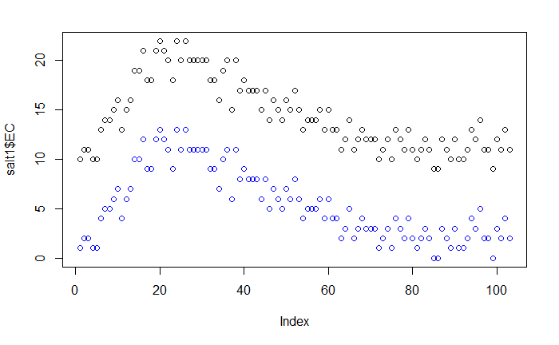

```r
file.list <- c("saltinject_jan23_1.csv","saltinject_march13_1.csv","saltinject_mar22_1.csv","saltinject_apr3_1.csv","saltinject_april20_2.csv","saltinject_april21_1.csv","saltinject_april28_1.csv","saltinject_may16_1.csv")
depth.file <- c("date_depth.csv")
depths <- read.csv(paste0("http://ecohydro.ires.ubc.ca/pdfs/salt_gauging/",depth.file))
salt1 <- read.csv(paste0("http://ecohydro.ires.ubc.ca/pdfs/salt_gauging/",file.list[1]))
plot(salt1$EC, ylim = c(0,max(salt1$EC)))
salt1$EC.adj <- salt1$EC - min(salt1$EC) # ECt - EC.0 like in Hudson paper
points(salt1$EC.adj, col = "blue")
```

```r
CF <- 0.486 # From Richardson et al., 2017, units = [mg/L] / [μS/cm]
# ct =(ECt -EC0)×CF (3) [From Hudson]
salt1$Ct <- salt1$EC.adj * CF
# to repeat for other salt measurements, just adjust the file.list[i] to read in the file, as:
salt2 <- read.csv(paste0("http://ecohydro.ires.ubc.ca/pdfs/salt_gauging/",file.list[2]))
```

Note: Electrical conductivity (EC) here is specific conductance (e.g. temperature-corrected electrical conductivity), with units of [μS cm-1 (micro-siemens per cm)]

Calibration factor to conver from EC to salt concentration: 0.486 mg·cm·μS-1·L-1 is the relationship between salt mass and specific conductance (see Richardson et al., 2017 in dropbox folder for assignment). Note units: mg·cm·μS-1·L-1 = [mg/L] / [μS/cm]

```r
t.int <- 5 # 5 seconds per reading
mass.salt <- 100 # grams of salt added for each salt injection
A1 <- sum(salt1$Ct)*t.int/1000
Q1 <- mass.salt/A1
```

# Assignment: Please submit a brief description of the approach and findings, including:

1. Discharge (Q) in L s-1 for the eight salt tracer additions
2. stage-discharge relationship in equation form (e.g. a rating curve equation), where stage = depth in mm
3. Bonus: Describe uncertainty of Q measurements

```
Ignoring unknown parameters: start
```

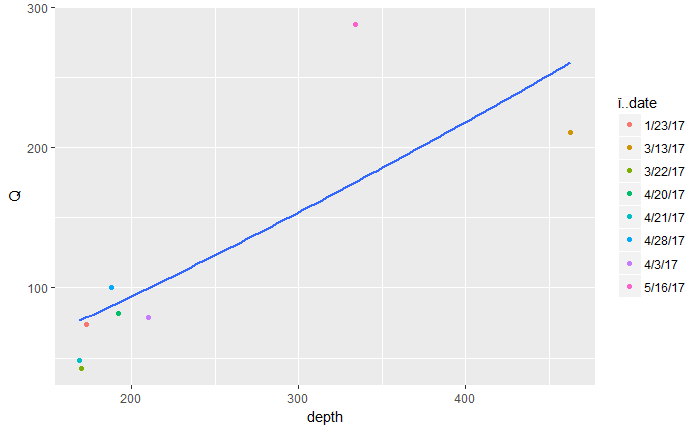

```r
depths %>% ggplot(aes(x = depth,y=Q)) + geom_point(aes(colour = `ï..date`)) +
    geom_smooth(method = 'nls', formula = y ~ a * x^b, start = list(a=1,b=2), se=FALSE)
```